# Notebook

**Was ist Maschinelles Lernen?**

Dr. Matthias Hölzl

[figure not shown]

## Die Ursprünge des maschinellen Lernens

- Ein Computer kann so programmiert werden, dass er lernt, besser Dame zu spielen, als der Programmierer, der das Programm geschrieben hat.  
  *(Arthur Samuel, 1959)*
- Das Programmieren von Computern, um aus Erfahrung zu lernen, sollte letztendlich die Notwendigkeit für einen Großteil dieses detaillierten Programmieraufwands beseitigen.  
  *(Arthur Samuel, 1959)*

Was ist Maschinelles Lernen?

## Eine mögliche Antwort (Andrew Glassner)

Der Begriff maschinelles Lernen beschreibt eine wachsende Zahl von Techniken, die alle ein Ziel haben: aussagekräftige Informationen aus Daten zu gewinnen.

„Daten“ bezieht sich hier auf alles, was aufgezeichnet und gemessen werden kann. [...]

"Sinnvolle Information" ist alles, was wir aus den Daten extrahieren können, was uns in irgendeiner Weise nützlich sein wird.

## Andrew Glassners Bücher

[figure not shown]

## Sinnvolle Information aus Daten (1)

[figure not shown]

Postleitzahlen erkennen, Schecks validieren, Gesichter erkennen

## Sinnvolle Information aus Daten (2)

[figure not shown]

Sprache verstehen, seltene Ereignisse erkennen, Vorhersagen treffen

## Eine andere Antwort (nach von François Chollet)

- Ein Teil der Künstlichen Intelligenz (KI)
- KI: Computer dazu bringen, Probleme zu lösen, die zuvor nur von Menschen gelöst werden konnten
- KI muss nicht lernen, z. B. Expertensysteme
- ML: Verhalten mit zusätzlichen Daten verbessern

## Biologische Inspiration

[figure not shown]

## Programm vs. Modell

[figure not shown]

## Programm vs. Modell

[figure not shown]

### Installation der benötigten Bibliotheken

```python
#!pip install matplotlib seaborn scikit-learn pandas numpy transformers huggingface_hub[hf_xet]
```

Installation von PyTorch mit CUDA-Unterstützung (falls GPU vorhanden)

```python
#!pip install torch torchvision --index-url https://download.pytorch.org/whl/cu129
```

Installation von PyTorch ohne CUDA-Unterstützung (CPU only)

```python
#!pip install torch torchvision
```

## Ausführen eines Programms

```python
def add(a, b):
    return a + b
```

```python
add(2, 3)
```

```
5
```

## Ausführen eines Modells

```python
# from transformers import pipeline
```

```python
# sentiment_analysis_model = pipeline("sentiment-analysis", model="microsoft/deberta-xlarge-mnli")
```

```python
# sentiment_analysis_model("I love machine learning!")
```

```python
# sentiment_analysis_model("I hate bad weather!")
```

```python
# sentiment_analysis_model("It's all right, I guess.")
```

## Programm vs. Modell

[figure not shown]

## Programm vs. Modell

[figure not shown]

## Programm vs. Modell

[figure not shown]

## Programm vs. Modell

[figure not shown]

## Beispiel: MNIST-Daten

[figure not shown]

Wir wollen handgeschriebene Ziffern erkennen:

## Regelbasierte Systeme: Feature Engineering

Extraktion relevanter Merkmale aus Daten durch Menschen.

[figure not shown]

Überwachtes Lernen

## Gelabelte Daten

[figure not shown]

## Trainieren eines Modells mit überwachtem Lernen

- Zeige einem Lern-Algorithmus viele mit Labels versehene Daten
- Prüfe, wie gut Labels anhand der Merkmale korrekt zuordnen kann
- Korrigiere die Parameter des Modells, wenn er falsch liegt

## Trainieren eines vordefinierten Modells

[figure not shown]

## Daten

- 10 Datensätze mit 1 Merkmal
- Jedes Merkmal ist eine Zahl zwischen 0.5 und 9.0
- Zu jedem Datensatz gehört ein Label (2.1 bis 19.2)

```python
data_x = [0.5, 1.4, 2.1, 3.5, 4.2, 5.1, 6.3, 7.6, 8.2, 9.0]
data_y = [2.1, 3.5, 5.8, 7.1, 9.3, 11.5, 13.2, 16.0, 17.1, 19.2]
```

```python
assert len(data_x) == len(data_y)
print(f"We have {len(data_x)} labeled data points.")
```

```
We have 10 labeled data points.
```

## Visualisierung der Daten

```python
import matplotlib.pyplot as plt
import seaborn as sns
```

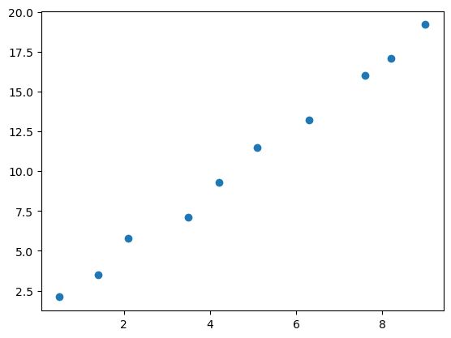

```python
plt.scatter(data_x, data_y)
plt.show()
```

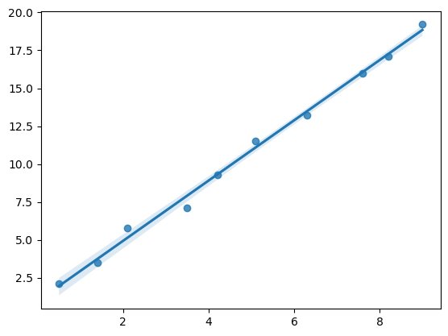

```python
sns.regplot(x=data_x, y=data_y)
plt.show()
```

## Aufteilen der Daten in Trainings- und Testdaten

- Nach dem Training muss das Modell bewertet werden
- Die Bewertung muss auf anderen Daten basieren als das Training
- Andernfalls könnte der Lernende nur die Beispiele speichern, die er gesehen hat
- Uns interessiert aber wie gut das Modell auf neuen Daten funktioniert (generalisiert)

```python
# Splitting the data: 6 for training, 4 for testing
train_x = [[x] for x in data_x[:6]]
train_y = data_y[:6]
train_x, train_y
```

```
([[0.5], [1.4], [2.1], [3.5], [4.2], [5.1]], [2.1, 3.5, 5.8, 7.1, 9.3, 11.5])
```

```python
test_x = [[x] for x in data_x[6:]]
test_y = data_y[6:]
test_x, test_y
```

```
([[6.3], [7.6], [8.2], [9.0]], [13.2, 16.0, 17.1, 19.2])
```

```python
print(f"Training samples: {len(train_x)}")
print(f"Test samples: {len(test_x)}")
```

```
Training samples: 6
Test samples: 4
```

## Trainieren des Modells

```python
from sklearn.linear_model import LinearRegression
```

```python
model = LinearRegression()
```

```python
try:
    print(model.coef_, model.intercept_)
except AttributeError:
    print("Model is not fitted yet.")
```

```
Model is not fitted yet.
```

```python
model.fit(train_x, train_y)
```

```
LinearRegression()
```

```python
model.coef_, model.intercept_
```

```
(array([1.97997416]), np.float64(1.0060723514211878))
```

## Bewerten des Modells

Reproduktion der Trainingsdaten:

```python
train_predictions = model.predict(train_x)
train_predictions
```

```
array([ 1.99605943,  3.77803618,  5.16401809,  7.93598191,  9.32196382,
       11.10394057])
```

Wie groß sind die Abweichungen?

```python
for pred, actual in zip(train_predictions, train_y):
    print(f"Predicted: {pred:.2f}, Actual: {actual:.2f}")
```

```
Predicted: 2.00, Actual: 2.10
Predicted: 3.78, Actual: 3.50
Predicted: 5.16, Actual: 5.80
Predicted: 7.94, Actual: 7.10
Predicted: 9.32, Actual: 9.30
Predicted: 11.10, Actual: 11.50
```

```python
total_abs_error = sum(abs(pred - actual) for pred, actual in zip(train_predictions, train_y))
print(f"Total Absolute Error: {total_abs_error:.2f}")
```

```
Total Absolute Error: 2.27
```

```python
total_squared_error = sum((pred - actual) ** 2 for pred, actual in zip(train_predictions, train_y))
print(f"Total Squared Error: {total_squared_error:.2f}")
```

```
Total Squared Error: 1.35
```

```python
mean_abs_error = total_abs_error / len(train_y)
print(f"Mean Absolute Error: {mean_abs_error:.2f}")
```

```
Mean Absolute Error: 0.38
```

```python
mse_manual = total_squared_error / len(train_y)
print(f"Mean Squared Error (manual): {mse_manual:.2f}")
```

```
Mean Squared Error (manual): 0.22
```

Scikit-Learn bietet viele Metriken zur Bewertung von Modellen an:

```python
from sklearn.metrics import mean_absolute_error, mean_squared_error
```

```python
mae = mean_absolute_error(train_y, train_predictions)
print(f"Mean Absolute Error: {mae:.2f}")
```

```
Mean Absolute Error: 0.38
```

```python
mse = mean_squared_error(train_y, train_predictions)
print(f"Mean Squared Error: {mse:.2f}")
```

```
Mean Squared Error: 0.22
```

## Bewerten des Modells

Wir sehen uns an, wie gut das Modell die Testdaten vorhersagen kann, die es noch nicht gesehen hat:

```python
predictions = model.predict(test_x)
predictions
```

```
array([13.47990956, 16.05387597, 17.24186047, 18.82583979])
```

```python
for pred, actual in zip(predictions, test_y):
    print(f"Predicted: {pred:.2f}, Actual: {actual:.2f}")
```

```
Predicted: 13.48, Actual: 13.20
Predicted: 16.05, Actual: 16.00
Predicted: 17.24, Actual: 17.10
Predicted: 18.83, Actual: 19.20
```

```python
mae = mean_absolute_error(test_y, predictions)
print(f"Mean Absolute Error: {mae:.2f}")
```

```
Mean Absolute Error: 0.21
```

```python
mse = mean_squared_error(test_y, predictions)
print(f"Mean Squared Error: {mse:.2f}")
```

```
Mean Squared Error: 0.06
```

## Trainieren eines eigenen Modells

[figure not shown]

```python
class LinearRegressionModel:
    """A scikit-learn-style simple linear regression model."""
    def __init__(self):
        self.w = None
        self.b = None

    def fit(self, X, y):
        """Trains the model using a grid search.

        Args:
            X (list of lists): Training data features, e.g., [[x1], [x2], ...].
            y (list): Training data targets, e.g., [y1, y2, ...].
        """
        best_w, best_b, min_loss = 0, 0, float('inf')
        possible_ws = [1.5, 1.8, 2.0, 2.2]
        possible_bs = [0.5, 1.0, 1.5]

        for w_guess in possible_ws:
            for b_guess in possible_bs:
                predictions = [w_guess * sample[0] + b_guess for sample in X]
                errors = [y[i] - predictions[i] for i in range(len(y))]
                mse = sum(e**2 for e in errors) / len(y)

                if mse < min_loss:
                    min_loss = mse
                    best_w, best_b = w_guess, b_guess

        self.w, self.b = best_w, best_b
        print(f"Learned parameters: w={self.w}, b={self.b}")
        return self

    def predict(self, X):
        """Makes predictions for a list of samples.

        Args:
            X (list of lists): Data features to predict on.

        Returns:
            A list of predictions.
        """
        if self.w is None or self.b is None:
            raise ValueError("Model has not been trained yet.")

        return [self.w * sample[0] + self.b for sample in X]
```

```python
custom_model = LinearRegressionModel()
```

```python
custom_model.fit(train_x, train_y)
```

```
Learned parameters: w=2.0, b=1.0
```

```
<__main__.LinearRegressionModel at 0x7734bd9b4550>
```

```python
custom_predictions = custom_model.predict(test_x)
custom_predictions
```

```
[13.6, 16.2, 17.4, 19.0]
```

```python
for pred, actual in zip(custom_predictions, test_y):
    print(f"Predicted: {pred:.2f}, Actual: {actual:.2f}")
```

```
Predicted: 13.60, Actual: 13.20
Predicted: 16.20, Actual: 16.00
Predicted: 17.40, Actual: 17.10
Predicted: 19.00, Actual: 19.20
```

```python
mae = mean_absolute_error(test_y, custom_predictions)
print(f"Mean Absolute Error: {mae:.2f}")
```

```
Mean Absolute Error: 0.27
```

```python
mse = mean_squared_error(test_y, custom_predictions)
print(f"Mean Squared Error: {mse:.2f}")
```

```
Mean Squared Error: 0.08
```

## Nochmal Test/Train-Split

- Das folgende Modell merkt sich einfach die Trainingsdaten und gibt sie bei der Vorhersage wieder aus.
- Es generalisiert nicht.

```python
class MemorizeModel:
    """A model that simply memorizes the training data."""
    def __init__(self):
        self.data = {}

    def fit(self, X, y):
        """Stores the training data in a dictionary.

        Args:
            X (list of lists): Training data features, e.g., [[x1], [x2], ...].
            y (list): Training data targets, e.g., [y1, y2, ...].
        """
        for i in range(len(X)):
            self.data[X[i][0]] = y[i]
        return self

    def predict(self, X):
        """Makes predictions by looking up the training data.

        Args:
            X (list of lists): Data features to predict on.

        Returns:
            A list of predictions.
        """
        return [self.data.get(sample[0], 0) for sample in X]
```

```python
memorize_model = MemorizeModel()
```

```python
memorize_model.fit(train_x, train_y)
```

```
<__main__.MemorizeModel at 0x7734902c2a10>
```

```python
memorize_predictions = memorize_model.predict(test_x)
memorize_predictions
```

```
[0, 0, 0, 0]
```

```python
for pred, actual in zip(memorize_predictions, test_y):
    print(f"Predicted: {pred:.2f}, Actual: {actual:.2f}")
```

```
Predicted: 0.00, Actual: 13.20
Predicted: 0.00, Actual: 16.00
Predicted: 0.00, Actual: 17.10
Predicted: 0.00, Actual: 19.20
```

```python
mae = mean_absolute_error(test_y, memorize_predictions)
print(f"Mean Absolute Error: {mae:.2f}")
```

```
Mean Absolute Error: 16.38
```

```python
mse = mean_squared_error(test_y, memorize_predictions)
print(f"Mean Squared Error: {mse:.2f}")
```

```
Mean Squared Error: 272.82
```

## Overfitting

- Ein Modell, das die Trainingsdaten perfekt vorhersagt, aber bei neuen Daten versagt, hat überangepasst (overfitted).
- Es hat die Trainingsdaten auswendig gelernt, anstatt die zugrunde liegenden Muster zu erkennen.
- Overfitting ist ein häufiges Problem im maschinellen Lernen.

## Verbesserung des Memorize-Modells

- Anstatt nur exakte Übereinstimmungen zurckzugeben, geben wir den Wert des nächsten Trainingspunkts zurück.
- Dies ist eine einfache Form von sogenanntem k-Nearest Neighbors (k-NN).

```python
import math
```

```python
class NearestNeighborModel:
    """A scikit-learn-style 1-Nearest Neighbor model."""
    def __init__(self):
        self.train_X = None
        self.train_y = None

    def fit(self, X, y):
        """Stores the training data."""
        self.train_X = X
        self.train_y = y
        return self

    def predict(self, X):
        """Predicts for each sample in X by finding its nearest neighbor."""
        predictions = []
        for sample_to_predict in X:
            best_dist = float('inf')
            best_y = None
            for i in range(len(self.train_X)):
                dist = abs(self.train_X[i][0] - sample_to_predict[0])
                if dist < best_dist:
                    best_dist = dist
                    best_y = self.train_y[i]
            predictions.append(best_y)
        return predictions
```

```python
nn_model = NearestNeighborModel()
```

```python
nn_model.fit(train_x, train_y)
```

```
<__main__.NearestNeighborModel at 0x7734902dde90>
```

```python
nn_predictions = nn_model.predict(test_x)
nn_predictions
```

```
[11.5, 11.5, 11.5, 11.5]
```

```python
mae = mean_absolute_error(test_y, nn_predictions)
print(f"Mean Absolute Error: {mae:.2f}")
```

```
Mean Absolute Error: 4.88
```

```python
mse = mean_squared_error(test_y, nn_predictions)
print(f"Mean Squared Error: {mse:.2f}")
```

```
Mean Squared Error: 28.45
```

Warum ist das NN-Modell immer noch so schlecht?

```python
for pred, actual in zip(nn_predictions, test_y):
    print(f"Predicted: {pred:.2f}, Actual: {actual:.2f}")
```

```
Predicted: 11.50, Actual: 13.20
Predicted: 11.50, Actual: 16.00
Predicted: 11.50, Actual: 17.10
Predicted: 11.50, Actual: 19.20
```

## Randomisierung des Datensatzes

- Die ursprünglichen Daten waren sortiert.
- Dadurch waren die Trainings- und Testdaten sehr unterschiedlich.
- Das Problem ist damit nicht, Werte zwischen den Trainingspunkten vorherzusagen, sondern aus dem Bereich der Trainingsdaten heraus zu extrapolieren.
- Durch Mischen der Daten wird dieses Problem behoben.

```python
import random
```

```python
combined = list(zip(data_x, data_y))
random.shuffle(combined)
data_x[:], data_y[:] = zip(*combined)
```

```python
data_x, data_y
```

```
([4.2, 0.5, 7.6, 3.5, 1.4, 8.2, 9.0, 2.1, 6.3, 5.1],
 [9.3, 2.1, 16.0, 7.1, 3.5, 17.1, 19.2, 5.8, 13.2, 11.5])
```

```python
train_x = [[x] for x in data_x[:6]]
train_y = data_y[:6]
train_x, train_y
```

```
([[4.2], [0.5], [7.6], [3.5], [1.4], [8.2]], [9.3, 2.1, 16.0, 7.1, 3.5, 17.1])
```

```python
test_x = [[x] for x in data_x[6:]]
test_y = data_y[6:]
test_x, test_y
```

```
([[9.0], [2.1], [6.3], [5.1]], [19.2, 5.8, 13.2, 11.5])
```

```python
print(f"Training samples: {len(train_x)}")
print(f"Test samples: {len(test_x)}")
```

```
Training samples: 6
Test samples: 4
```

```python
nn_model = NearestNeighborModel()
nn_model.fit(train_x, train_y)
nn_predictions = nn_model.predict(test_x)
nn_predictions
```

```
[17.1, 3.5, 16.0, 9.3]
```

```python
mae = mean_absolute_error(test_y, nn_predictions)
print(f"Mean Absolute Error: {mae:.2f}")
```

```
Mean Absolute Error: 2.35
```

```python
mse = mean_squared_error(test_y, nn_predictions)
print(f"Mean Squared Error: {mse:.2f}")
```

```
Mean Squared Error: 5.59
```

```python
for pred, actual in zip(nn_predictions, test_y):
    print(f"Predicted: {pred:.2f}, Actual: {actual:.2f}")
```

```
Predicted: 17.10, Actual: 19.20
Predicted: 3.50, Actual: 5.80
Predicted: 16.00, Actual: 13.20
Predicted: 9.30, Actual: 11.50
```

```python
custom_model = LinearRegressionModel()
custom_model.fit(train_x, train_y)
custom_predictions = custom_model.predict(test_x)
custom_predictions
```

```
Learned parameters: w=2.0, b=0.5
```

```
[18.5, 4.7, 13.1, 10.7]
```

```python
mae = mean_absolute_error(test_y, custom_predictions)
print(f"Mean Absolute Error: {mae:.2f}")
```

```
Mean Absolute Error: 0.67
```

```python
mse = mean_squared_error(test_y, custom_predictions)
print(f"Mean Squared Error: {mse:.2f}")
```

```
Mean Squared Error: 0.59
```

## Der ML Workflow

[figure not shown]

## Der ML Workflow

[figure not shown]

## Auswahl eines Modells

[figure not shown]

## Auswahl eines Modells

[figure not shown]

## Auswahl eines Modells

[figure not shown]

## Auswahl eines Modells

[figure not shown]